# TCGAmutations: R Data package for TCGA somatic mutations

Anand Mayakonda

2018-08-18

# 1 Introduction

`TCGAmutations` is an R data package containing somatic mutations from TCGA cohorts. This is particularly useful for those working with mutation data from TCGA studies - where most of the time is spent on searching various databases, downloading, compiling and tidying up the data before even the actual analysis is started. This package tries to mitigate the issue by providing pre-compiled, curated somatic mutations from 32 TCGA cohorts along with relevant clinical information for all sequenced samples.

# 2 Requirements

Only dependency is Bioconductor package [maftools](http://www.bioconductor.org/packages/release/bioc/html/maftools.html) and all TCGA cohorts are stored as MAF objects. You can install stable version of maftools package from Bioconductor if you do not have it installed already.

```r
source("https://bioconductor.org/biocLite.R")
biocLite("maftools")
```

Or you can install it from GitHub for developmental version.

```r
devtools::install_github(repo = "PoisonAlien/maftools")
```

# 3 usage

Usage is simple. Type `tcga_available` to see available datasets, and `tcga_load` to load a desired dataset.

## 3.1 Availbale datasets

```r
library(maftools)
library(TCGAmutations)

TCGAmutations::tcga_available()
```

```
##     Study_Abbreviation
##  1:                ACC
##  2:               BLCA
##  3:               BRCA
##  4:               CESC
##  5:               CHOL
##  6:               COAD
##  7:               DLBC
##  8:               ESCA
##  9:                GBM
## 10:               HNSC
## 11:               KICH
## 12:               KIRC
## 13:               KIRP
## 14:               LAML
```

[output cut: 93 more lines]

## 3.2 Loading a dataset

```r
TCGAmutations::tcga_load(study = "LAML")
```

```
## Loading objects:
##   tcga_laml_mc3
```

```
## Successfully loaded TCGA LAML!
```

```r
#Typing tcga_laml prints summary of the object
tcga_laml_mc3
```

[output not shown]

## 3.3 MAF object

Every TCGA cohort is stored and loaded as an MAF object. MAF object includes data.table of somatic variants and clinical information associated with each sample in MAF. There are accessor methods to access elements of MAF object.

```r
#Shows sample summary
getSampleSummary(x = tcga_laml_mc3)
```

```
##      Tumor_Sample_Barcode Frame_Shift_Del Frame_Shift_Ins In_Frame_Del
##   1:         TCGA-AB-2808              37              84            0
##   2:         TCGA-AB-2828              23              81            2
##   3:         TCGA-AB-2826              22              54            1
##   4:         TCGA-AB-2806              15              27            0
##   5:         TCGA-AB-2833              10              43            0
##  ---
## 133:         TCGA-AB-2845               0               0            0
## 134:         TCGA-AB-2892               0               1            0
## 135:         TCGA-AB-2894               0               0            0
## 136:         TCGA-AB-2944               0               0            0
## 137:         TCGA-AB-2948               0               0            0
##      In_Frame_Ins Missense_Mutation Nonsense_Mutation Nonstop_Mutation
##   1:            0               581                34                2
##   2:            1               578                31                0
```

[output cut: 21 more lines]

```r
#Shows gene summary
getGeneSummary(x = tcga_laml_mc3)
```

```
##       Hugo_Symbol Frame_Shift_Del Frame_Shift_Ins In_Frame_Del
##    1:      DNMT3A               1               0            0
##    2:       BPIFC               0               0            0
##    3:         TTN               0               4            0
##    4:        TP53               1               0            0
##    5:       RUNX1               0               2            1
##   ---
## 4138:     ZSCAN25               0               0            0
## 4139:     ZSCAN31               0               0            0
## 4140:      ZSWIM5               0               0            0
## 4141:      ZSWIM6               0               0            0
## 4142:         ZYX               0               0            0
##       In_Frame_Ins Missense_Mutation Nonsense_Mutation Nonstop_Mutation
##    1:            0                 8                 1                0
##    2:            0                 0                 0                0
```

[output cut: 33 more lines]

```r
#Clinical data; printing only first ten columns for display convenience
getClinicalData(x = tcga_laml_mc3)[1:10, 1:10]
```

```
##     additional_studies tumor_tissue_site tumor_tissue_site_other
##  1:               <NA>       Bone_Marrow                    <NA>
##  2:               <NA>       Bone_Marrow                    <NA>
##  3:               <NA>       Bone_Marrow                    <NA>
##  4:               <NA>       Bone_Marrow                    <NA>
##  5:               <NA>       Bone_Marrow                    <NA>
##  6:               <NA>       Bone_Marrow                    <NA>
##  7:               <NA>       Bone_Marrow                    <NA>
##  8:               <NA>       Bone_Marrow                    <NA>
##  9:               <NA>       Bone_Marrow                    <NA>
## 10:               <NA>       Bone_Marrow                    <NA>
##     leukemia_specimen_cell_source_type other_dx gender vital_status
##  1:               Bone_marrow_aspirate       No   MALE        Alive
##  2:               Bone_marrow_aspirate       No   MALE         Dead
##  3:               Bone_marrow_aspirate      Yes   MALE         Dead
```

[output cut: 18 more lines]

See `maftools` vignette for complete details. You can type `browseVignettes(package = "maftools")` for an html vignette. Briefly, you can pass the loaded MAF object into any of the functions from maftools package for analysis and plotting. Below image describes available functions.

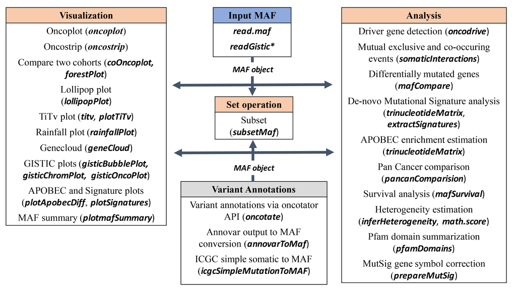

# 4 FAQ

## 4.1 Data source

There are two sources from which MAF files were compiled:

- [Broad Firehose](http://firebrowse.org/)
- [TCGA MC3](https://gdc.cancer.gov/about-data/publications/mc3-2017)

### 4.1.1 FireHose

All MAF files from “latest” analysis were downloaded from Broad firehose using `firehose_get` tool (here it was “analyses__2016_01_28“). These are the MAFs that were used to generate significanly mutated driver genes for each cohort with MutSig2CV.

```bash
firehose_get -tasks mutsig analyses latest
```

Once downloaded, “*-T[P/B/M]-final_analysis_set.maf" files for each cohort was further processed while keeping only required columns, along with Protein_Change information, depth and variant allele frequency details for each variant. This was done as to minimize MAF object size while keeping relevant information.

#### 4.1.1.1 Sample types

All cohorts except SKCM (Skin_Cutaneous_Melanoma) and LAML (Acute_Myeloid_Leukemia) are of type Primary Solid Tumor (TCGA sample type code 01; short letter code TP).

- All samples from SKCM are of Metastatic type. (TCGA sample type code 06; short letter code TM)
- All samples from LAML are of Primary Blood Derived Cancer - Peripheral Blood type. (TCGA sample type code 03; short letter code TB)

### 4.1.2 MC3

MC3 Public MAF file was downloaded from [gdc](https://gdc.cancer.gov/about-data/publications/mc3-2017) and seperated into cohorts. Tumor Sample Barcodes are restricted to first 12 characters, however original barcode is kept as is under `Tumor_Sample_Barcode_full` column. To save size of MAF objects, columns were restricted to below entries,

```
"Hugo_Symbol", "Chromosome", "Start_Position", "End_Position", "Reference_Allele", "Tumor_Seq_Allele2", "Variant_Classification", "Variant_Type", "Tumor_Sample_Barcode", "HGVSp_Short", "n_depth", "n_ref_count", "n_alt_count", "t_depth", "t_ref_count", "t_alt_count", "Tumor_Sample_Barcode_full", "sample_type_description", "ExAC_AF", "GMAF", "Cohort", "IMPACT"
```

## 4.3 Support

If you have any issues, questions please feel free to raise an [issue](https://github.com/PoisonAlien/TCGAmutations/issues) on [GitHub](https://github.com/PoisonAlienTCGAmutations/) page.

## 4.4 References

Scalable Open Science Approach for Mutation Calling of Tumor Exomes Using Multiple Genomic Pipelines Kyle Ellrott, Matthew H. Bailey, Gordon Saksena, Kyle R. Covington, Cyriac Kandoth, Chip Stewart, Julian Hess, Singer Ma, Michael McLellan, Heidi J. Sofia, Carolyn Hutter, Gad Getz, David Wheeler, Li Ding, the MC3 Working Group and The Cancer Genome Atlas Research Network The Cancer Genome Atlas Research Network. Cell Syst. 2018 Mar 28; 6(3): 271–281.e7. doi: 10.1016/j.cels.2018.03.002